# Calibrate CNN predictions for Rhizaria

Thelma Panaiotis

25/08/2022

## Prepare data

Read predictions and scores of calibration data

```r
# Read taxo match to change EcoTaxa names to nice names
tc <- read_sheet(ss)
```

```
## Auto-refreshing stale OAuth token.
```

```
## ✔ Reading from "Taxo match".
```

```
## ✔ Range 'tc'.
```

```r
# True classification
df_true <- read_parquet("data/rhizaria_calibration_data.parquet") %>%
  select(object_id = orig_id, classif_id_1) %>%
  left_join(tc %>% select(classif_id_1, y_true = new_taxon)) %>%
  select(-classif_id_1)
# Predictions
df_pred <- read_tsv("data/ecotaxa_rhizaria_calibration.tsv", comment = "[") %>% select(object_id, y_pred = object_annotation_category, score = object_cnn_score)
# Join truth and predictions
df <- left_join(df_true, df_pred)
```

Within each taxon, order by score and compute cumulative error as well as rank.

```r
calib_preds <- df %>%
  # Group by taxon
  group_by(y_pred) %>%
  # Sort by score
  arrange(score) %>%
  # Compute cumulative error in % and rank in %
  mutate(
    error = y_true != y_pred,
    cum_error = cumsum(error),
    nb_error = max(cum_error),
    cum_error = ifelse(nb_error>0, cum_error/nb_error, 1), # Treat cases of zero division when all objects are correctly predicted
    percent_rank=1:n()/n()
  ) %>%
  ungroup() %>%
  # Count objects per true class
  add_count(y_true) %>%
  select(-nb_error)
```

## Inspect data

Count objects in each true and predicted class and plot them

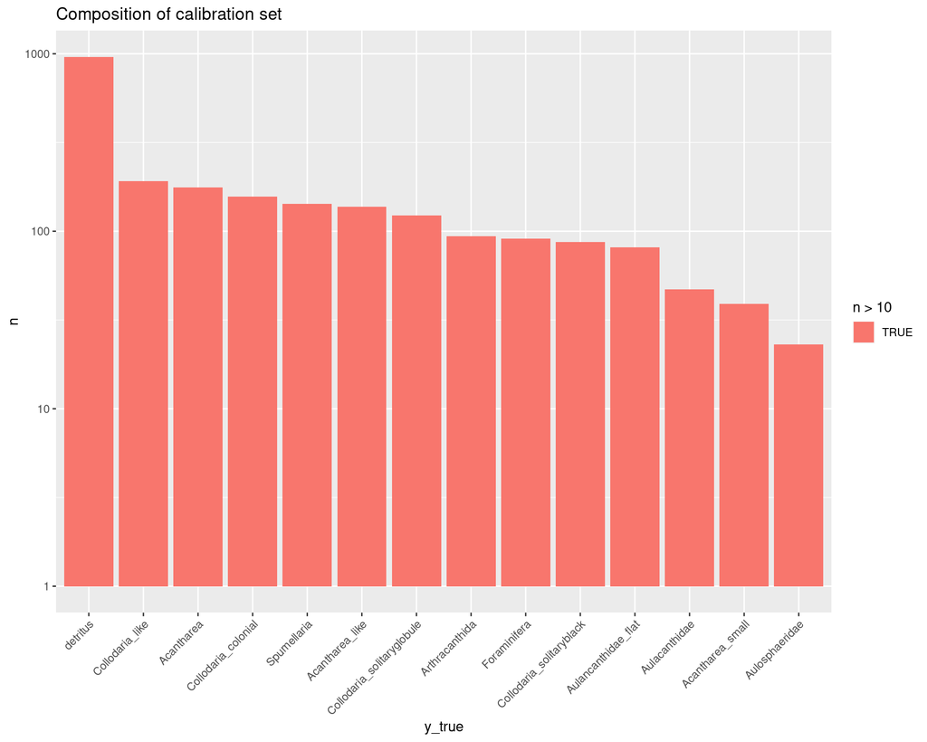

```r
counts_y_true <- calib_preds %>%
  count(y_true) %>%
  arrange(desc(n)) %>%
  mutate(y_true = fct_inorder(y_true))

counts_y_true %>%
  ggplot() +
  geom_col(aes(x = y_true, y = n, fill = n > 10)) +
  scale_y_log10() +
  theme(axis.text.x = element_text(angle = 45, vjust = 1, hjust=1)) +
  labs(title = "Composition of calibration set")
```

*0 classes have fewer than 10 objects: computing a threshold for theses classes will be difficult.*

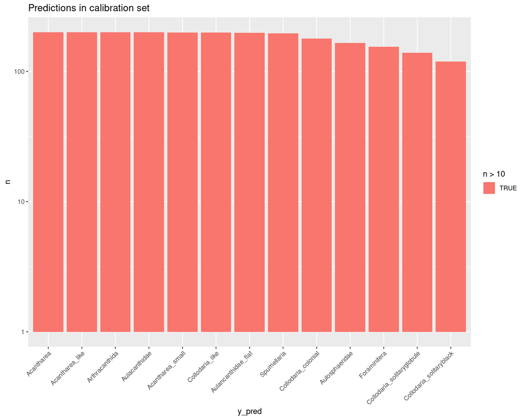

```r
counts_y_pred <- calib_preds %>%
  count(y_pred) %>%
  arrange(desc(n)) %>%
  mutate(y_pred = fct_inorder(y_pred))

counts_y_pred %>%
  ggplot() +
  geom_col(aes(x = y_pred, y = n, fill = n > 10)) +
  scale_y_log10() +
  theme(axis.text.x = element_text(angle = 45, vjust = 1, hjust=1)) +
  labs(title = "Predictions in calibration set")
```

*More objects are predicted in plankton classes than the ones in true classes: the classifier has a good recall, and the calibration step will improve precision.*

Now look at scores distribution for each taxon.

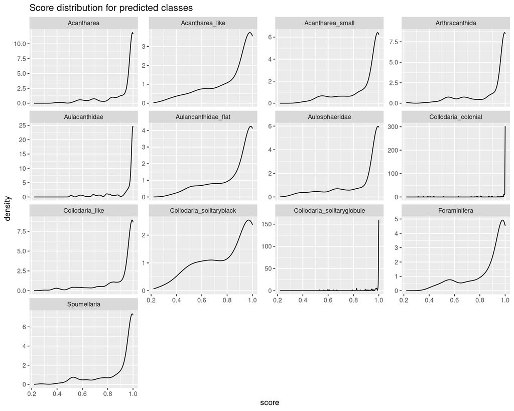

```r
calib_preds %>%
  ggplot() +
  geom_density(aes(x = score)) +
  facet_wrap(~y_pred, scales = "free_y") +
  labs(title = "Score distribution for predicted classes")
```

## Global view for thresholding

For each taxon plot cumulative error VS prediction score.

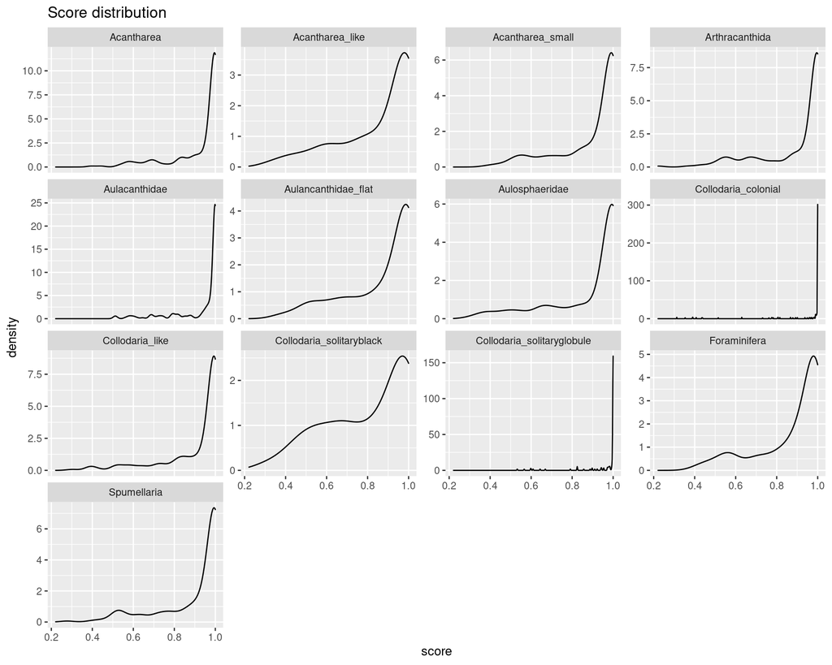

```r
calib_preds %>%
  ggplot() +
  geom_density(aes(x = score)) +
  facet_wrap(~y_pred, scales = "free_y") +
  labs(title = "Score distribution")
```

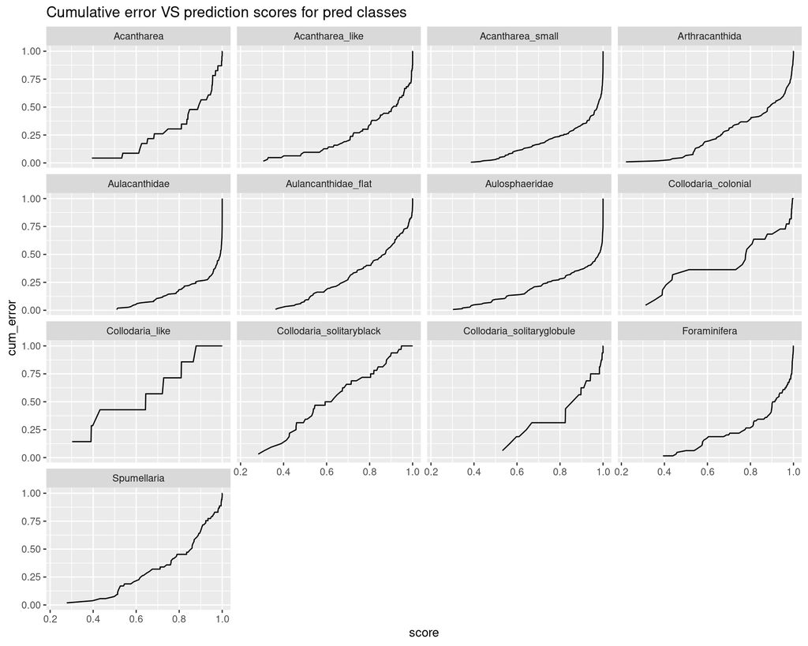

```r
calib_preds %>%
  ggplot() +
  geom_path(aes(x = score, y = cum_error)) +
  facet_wrap(~y_pred) +
  scale_color_continuous(trans = "log1p") +
  labs(title = "Cumulative error VS prediction scores for pred classes")
```

And plot cumulative error VS object rank.

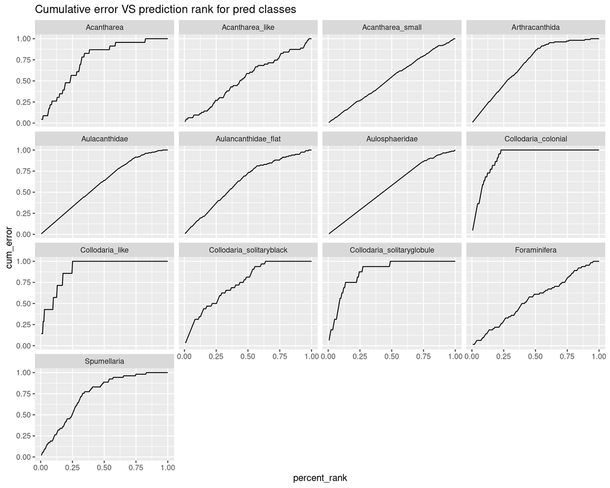

```r
calib_preds %>%
  ggplot() +
  geom_path(aes(x = percent_rank, y = cum_error)) +
  facet_wrap(~y_pred) +
  scale_color_continuous(trans = "log1p") +
  labs(title = "Cumulative error VS prediction rank for pred classes")
```

## Thresholding by taxon

Make a list of taxa.

```r
taxa <- calib_preds %>% pull(y_pred) %>% unique() %>% sort()
taxa
```

```
##  [1] "Acantharea"                 "Acantharea_like"
##  [3] "Acantharea_small"           "Arthracanthida"
##  [5] "Aulacanthidae"              "Aulancanthidae_flat"
##  [7] "Aulosphaeridae"             "Collodaria_colonial"
##  [9] "Collodaria_like"            "Collodaria_solitaryblack"
## [11] "Collodaria_solitaryglobule" "Foraminifera"
## [13] "Spumellaria"
```

There are 13 taxa to compute threshold for.

Define a base error threshold and prepare a tibble to store computed thresholds.

```r
error_threshold_base <- 0.9

taxa_threshold <- tibble(
  taxa,
  error_threshold = NA,
  score_threshold = NA,
  keep_threshold = NA,
  )
```

For each taxon, start with an error threshold of 90%. Plot cumulative error VS score and VS rank and compute the score threshold associated with this error threshold and the proportion of objects that will be kept.

```r
plot_threshold <- function(taxon, error_threshold = 0.9){
  #' Plot cumulative error VS score and VS rank for a given error threshold.
  #' Return the score threshold associated with this error threshold
  #' and the proportion of objects that will be kept.

  calib_taxa <- calib_preds %>%
    filter(y_pred == taxon) %>%
    mutate(keep = cum_error >= error_threshold)

  # Compute associated score threshold and proportion of kept data.
  score_threshold <- calib_taxa %>% filter(keep) %>% slice(1) %>% pull(score)
  keep_threshold <- calib_taxa %>% filter(keep) %>% slice(1) %>% pull(percent_rank)

  # If error_threshold was set to 0, keep all objects
  if (error_threshold == 0) {
    score_threshold = 0
    keep_threshold = 0
  }

  # Number of true objects for this taxon
  n <- nrow(calib_taxa)


  if (n > 20000){ # if too many objects, do not plot
    plot <- NULL
  } else {
    p1 <- calib_taxa %>%
      ggplot() +
      geom_vline(aes(xintercept = score_threshold)) +
      geom_label(aes(x = 1, y = 0, label = format(score_threshold, digits = 2)))

    p2 <- calib_taxa %>%
      ggplot() +
      geom_vline(aes(xintercept = keep_threshold)) +
      geom_label(aes(x = 1, y = 0, label = str_c("Keep ", percent(1-keep_threshold, digits = 2), " of objects")))

    if (n < 1000){ # for few objects, plot points
      p1 <- p1 + geom_point(aes(x = score, y = cum_error, colour = cum_error < error_threshold), show.legend = F)
      p2 <- p2 + geom_point(aes(x = percent_rank, y = cum_error, colour = cum_error < error_threshold), show.legend = F)
    } else { # else, plot a path
      p1 <- p1 + geom_path(aes(x = score, y = cum_error, colour = cum_error < error_threshold), show.legend = F)
      p2 <- p2 + geom_path(aes(x = percent_rank, y = cum_error, colour = cum_error < error_threshold), show.legend = F)
    }

    # Make 2 plots side by side
    plot <- grid.arrange(p1, p2, ncol=2, top = textGrob(paste0(taxon, " (n = ", n, ")"), gp=gpar(fontsize=18)))
  }
  return(list(plot, score_threshold, keep_threshold))
}
```

### Acantharea

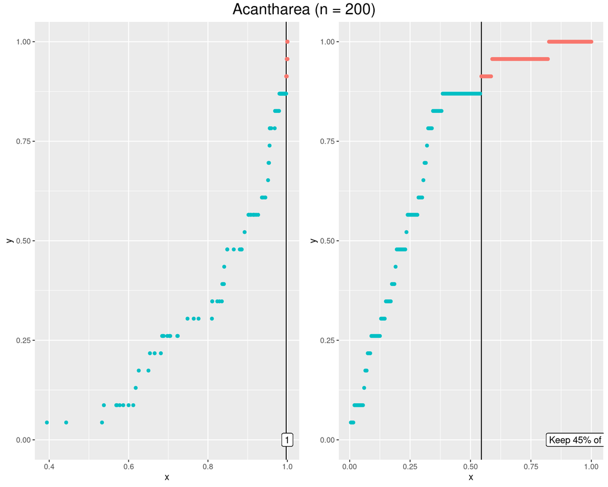

Ok for error threshold at 90%.

### Acantharea_like

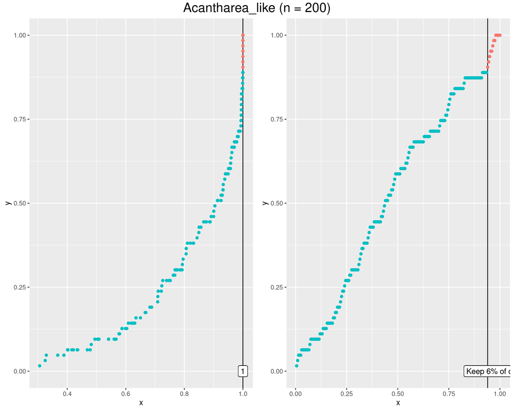

### Acantharea_small

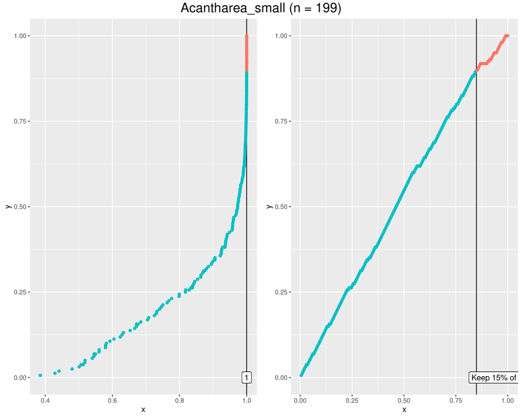

### Arthracanthida

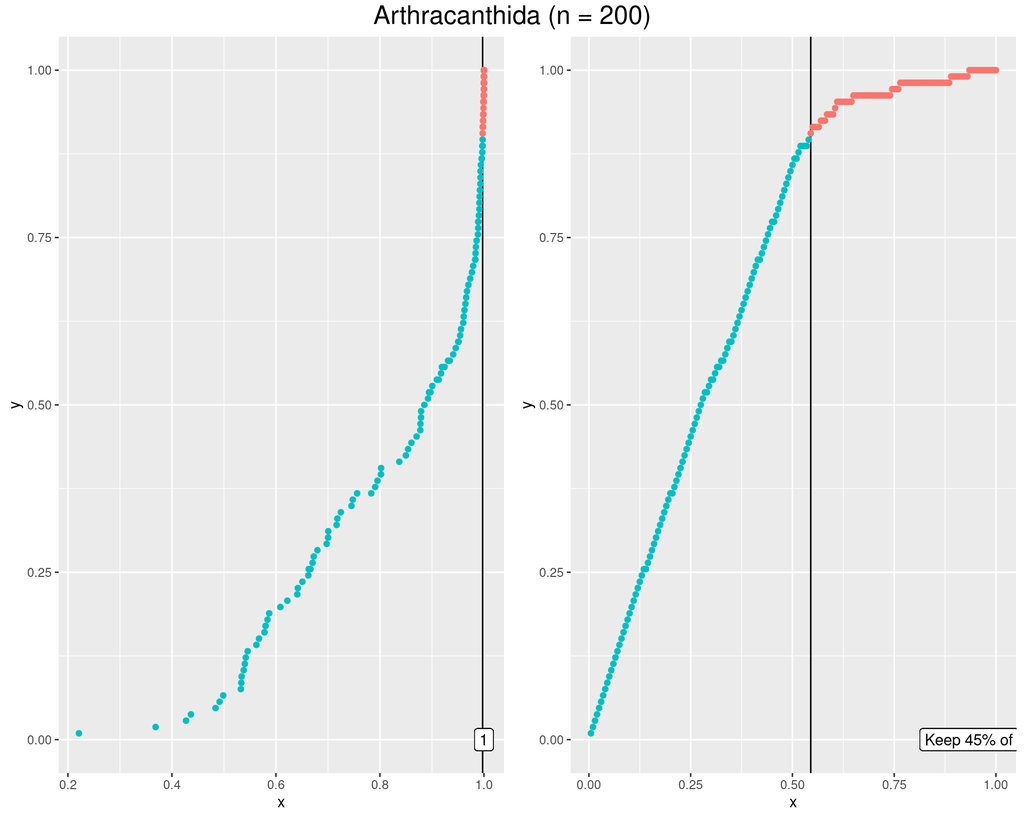

### Aulacanthidae

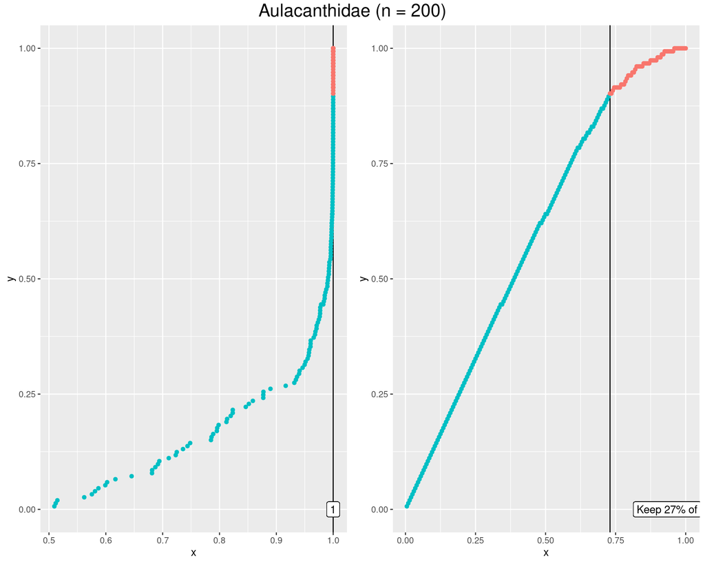

### Aulacanthidae_flat

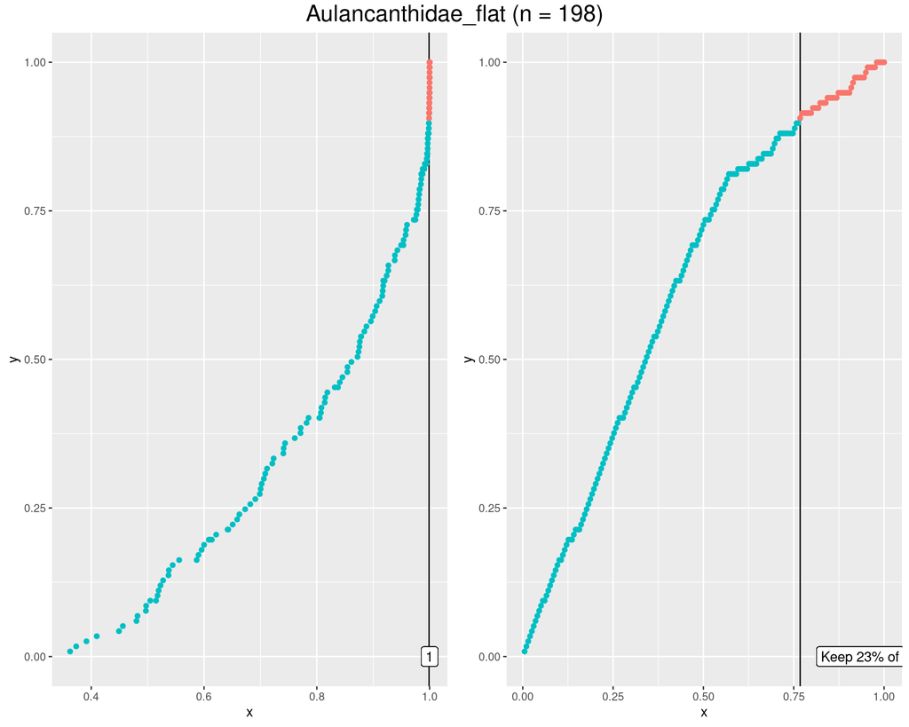

### Aulosphaeridae

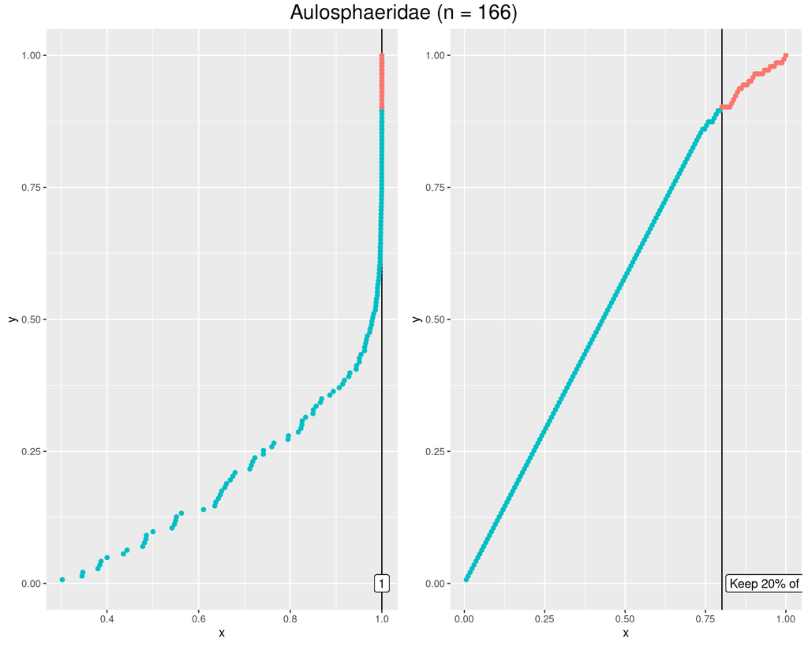

Ignore these.

### Collodaria_colonial

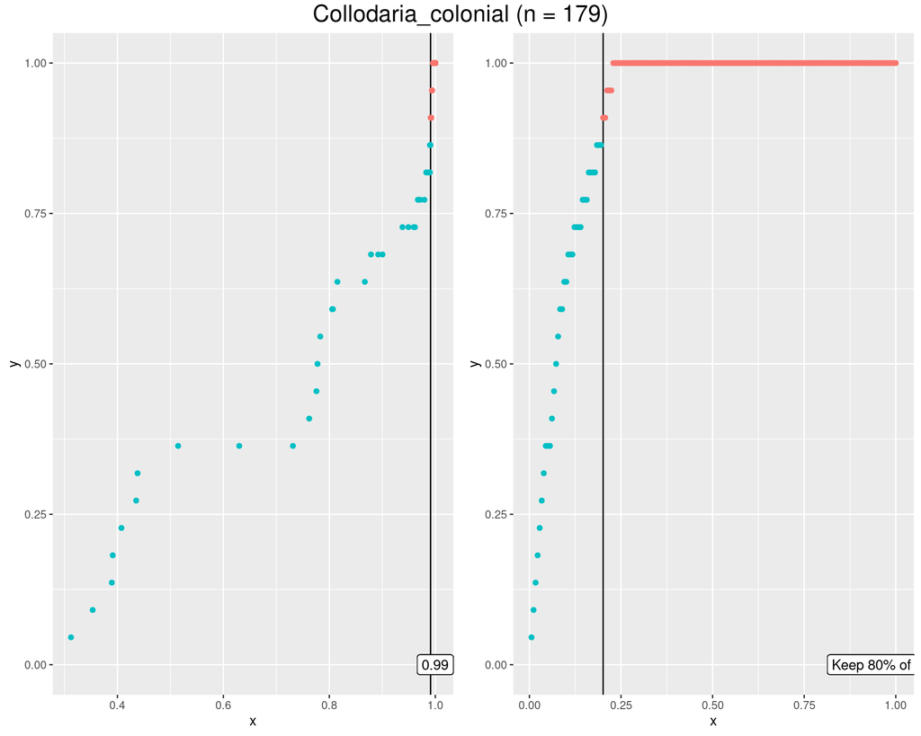

### Collodaria_like

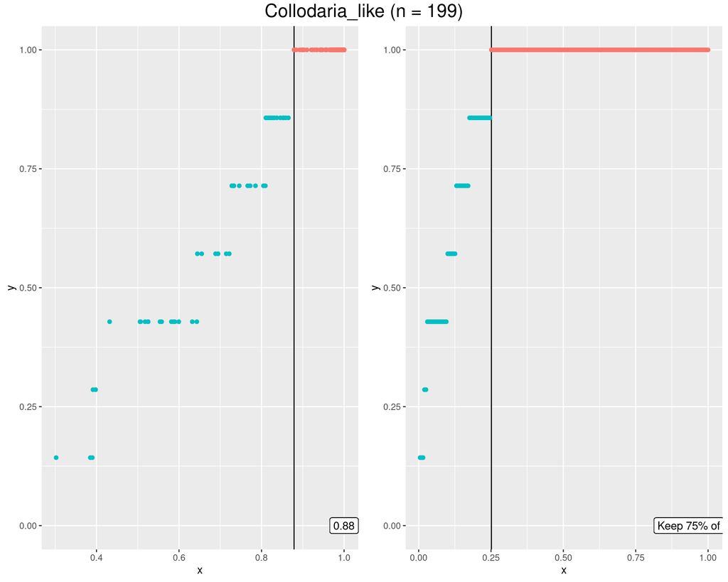

Ok for error threshold at 90%.

### Collodaria_solitaryblack

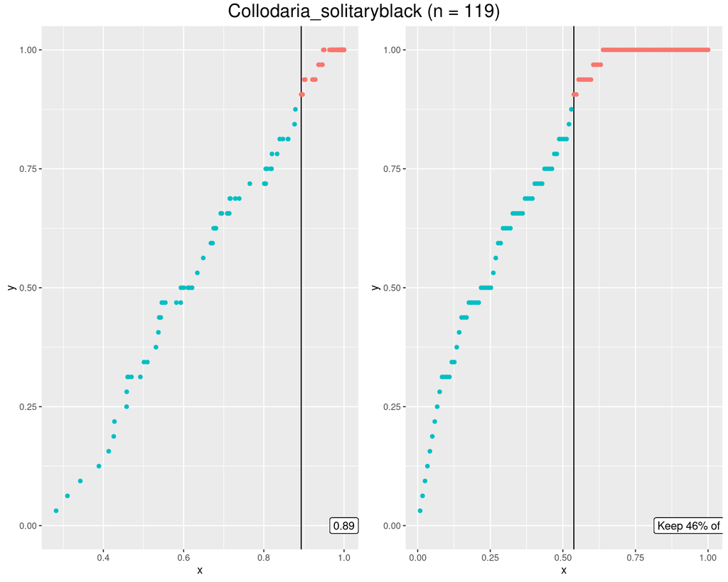

### Collodaria_solitaryglobule

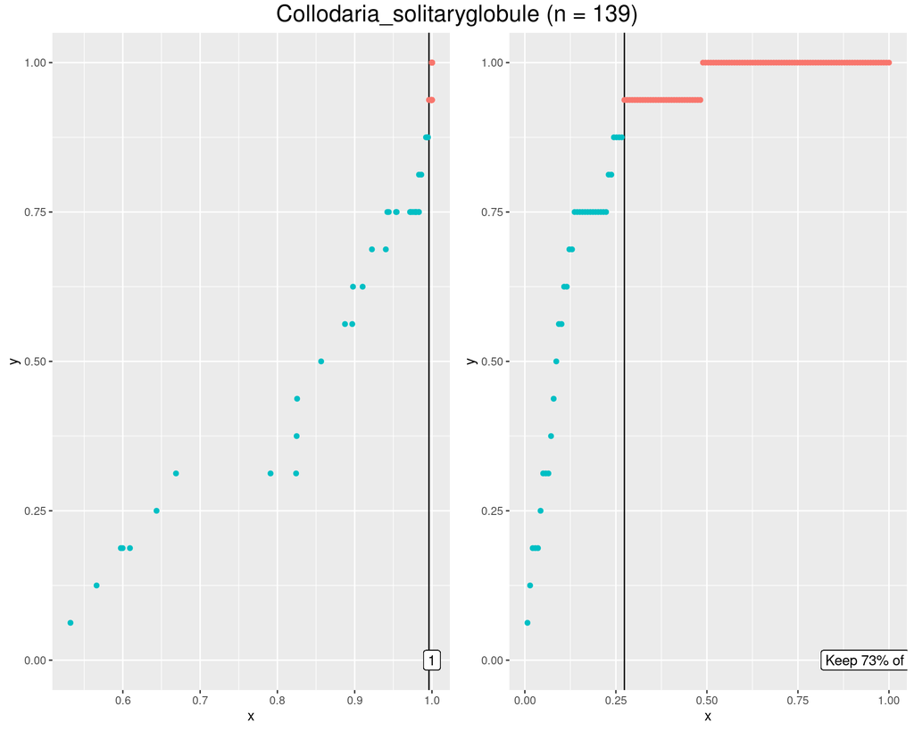

### Foraminifera

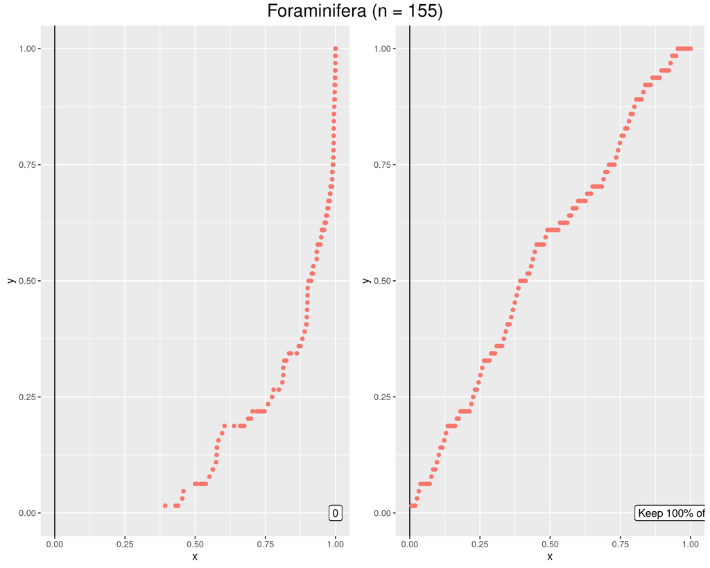

### Spumellaria

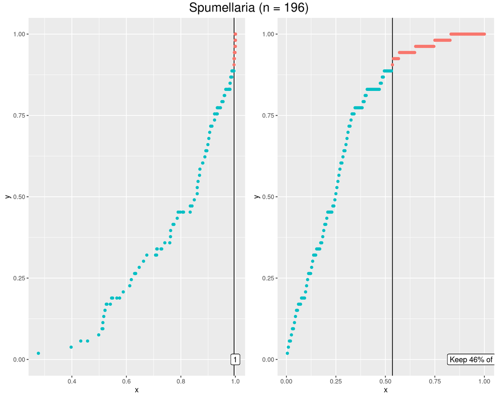

Ok for error threshold at 90%.

## Thresholding summary

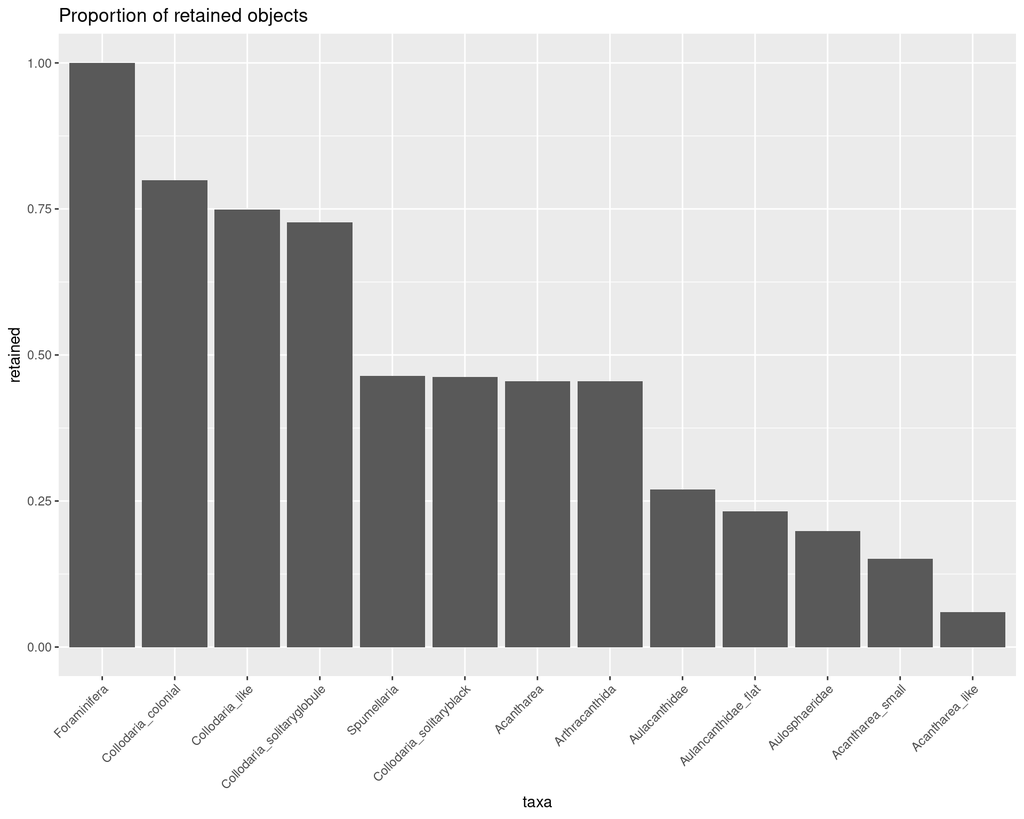

```r
taxa_threshold <- taxa_threshold %>%
  #mutate(plankton = taxa %in% calibration_data$plankton_classes) %>%
  mutate(retained = 1 - keep_threshold) %>%
  mutate(usable = retained > 0.1)

#write_csv(taxa_threshold, file = "data/taxa_threshold.csv")

taxa_threshold %>%
  arrange(-retained) %>%
  mutate(taxa = factor(taxa, levels = taxa)) %>%
  ggplot() +
  geom_col(aes(x = taxa, y = retained)) +
  theme(axis.text.x = element_text(angle = 45, vjust = 1, hjust=1)) +
  labs(title = "Proportion of retained objects")
```